# customer_insights_eda

## Exploratory Data Analysis (EDA) — Statistical Analysis

**Key Goals:**

- Explore customer demographics and behavior through descriptive statistics
- Visualize spending patterns, purchase frequency, and demographic distribution
- Segment customers using data-driven quantitative methods
- Run hypothesis tests to examine relationships between:
  - Age and spending
  - Gender and transaction frequency
  - Geography and customer engagement
- Translate findings into clear, statistically sound business insights

### Import the essential libraries

```python
import pandas as pd
import matplotlib.pyplot as plt
import numpy as np
import seaborn as sns
import warnings
warnings.filterwarnings('ignore')
```

## Understanding the Data

### Load and preview the dataset

```python
df=pd.read_csv("US_Customer_Insights_Dataset.csv")
```

```python
df
```

|  | CustomerID | Name | State | Education | Gender | Age | Married | NumPets | JoinDate | TransactionDate | MonthlySpend | DaysSinceLastInteraction |
| --- | --- | --- | --- | --- | --- | --- | --- | --- | --- | --- | --- | --- |
| 0 | CUST10319 | Scott Perez | Florida | High School | Non-Binary | 47 | Yes | 1 | 9/19/21 | 9/2/24 | 1281.74 | 332 |
| 1 | CUST10695 | Jennifer Burton | Washington | Master | Male | 72 | Yes | 0 | 4/5/24 | 6/2/24 | 429.46 | 424 |
| 2 | CUST10297 | Michelle Rogers | Arizona | Master | Female | 40 | Yes | 2 | 7/24/24 | 2/28/25 | 510.34 | 153 |
| 3 | CUST10103 | Brooke Hendricks | Texas | Master | Male | 27 | Yes | 0 | 8/12/23 | 3/29/25 | 396.47 | 124 |
| 4 | CUST10219 | Karen Johns | Texas | High School | Female | 28 | Yes | 1 | 12/6/21 | 7/24/22 | 139.68 | 1103 |
| ... | ... | ... | ... | ... | ... | ... | ... | ... | ... | ... | ... | ... |
| 10670 | CUST10833 | Steven Burns | Georgia | PhD | Female | 60 | No | 1 | 8/24/23 | 2/29/24 | 341.28 | 518 |
| 10671 | CUST10620 | Jesse Pratt | Texas | Master | Male | 64 | No | 0 | 4/13/23 | 12/31/24 | 468.04 | 212 |
| 10672 | CUST10449 | John Lloyd | Arizona | Master | Non-Binary | 31 | Yes | 0 | 7/3/22 | 9/21/23 | 259.94 | 679 |
| 10673 | CUST10020 | Christopher Sparks | Florida | Bachelor | Female | 31 | No | 0 | 9/19/23 | 12/29/23 | 494.17 | 580 |
| 10674 | CUST10267 | Melissa Marshall | Arizona | Associate | Non-Binary | 57 | Yes | 1 | 4/3/23 | 12/1/23 | 153.12 | 608 |

10675 rows × 12 columns

**Insights:**  
The dataset contains 10675 rows(Customer records) and 12 columns.  
Customer information includes demographics, spending Abehaviour, engagement, and pet ownership.

```python
df.head()
```

|  | CustomerID | Name | State | Education | Gender | Age | Married | NumPets | JoinDate | TransactionDate | MonthlySpend | DaysSinceLastInteraction |
| --- | --- | --- | --- | --- | --- | --- | --- | --- | --- | --- | --- | --- |
| 0 | CUST10319 | Scott Perez | Florida | High School | Non-Binary | 47 | Yes | 1 | 9/19/21 | 9/2/24 | 1281.74 | 332 |
| 1 | CUST10695 | Jennifer Burton | Washington | Master | Male | 72 | Yes | 0 | 4/5/24 | 6/2/24 | 429.46 | 424 |
| 2 | CUST10297 | Michelle Rogers | Arizona | Master | Female | 40 | Yes | 2 | 7/24/24 | 2/28/25 | 510.34 | 153 |
| 3 | CUST10103 | Brooke Hendricks | Texas | Master | Male | 27 | Yes | 0 | 8/12/23 | 3/29/25 | 396.47 | 124 |
| 4 | CUST10219 | Karen Johns | Texas | High School | Female | 28 | Yes | 1 | 12/6/21 | 7/24/22 | 139.68 | 1103 |

### Check data types, unique values, and presence of nulls

```python
# Checking the datatypes
df.info()
```

```
<class 'pandas.core.frame.DataFrame'>
RangeIndex: 10675 entries, 0 to 10674
Data columns (total 12 columns):
 #   Column                    Non-Null Count  Dtype
---  ------                    --------------  -----
 0   CustomerID                10675 non-null  object
 1   Name                      10675 non-null  object
 2   State                     10675 non-null  object
 3   Education                 10675 non-null  object
 4   Gender                    10675 non-null  object
 5   Age                       10675 non-null  int64
 6   Married                   10675 non-null  object
 7   NumPets                   10675 non-null  int64
 8   JoinDate                  10675 non-null  object
 9   TransactionDate           10675 non-null  object
 10  MonthlySpend              10675 non-null  float64
 11  DaysSinceLastInteraction  10675 non-null  int64
dtypes: float64(1), int64(3), object(8)
memory usage: 1000.9+ KB
```

**Insights:**  
The dataset has 3 data types - object, int & float.  
The datatype of 'JoinDate' & 'TransactionDate' are Object, and need to be changed to datetime format.

```python
# Changing the Date columns datatype to datetime format
df['JoinDate'] = pd.to_datetime(df['JoinDate'], format = '%m/%d/%y')
df['TransactionDate'] = pd.to_datetime(df['TransactionDate'], format = '%m/%d/%y')
df.info()
```

```
<class 'pandas.core.frame.DataFrame'>
RangeIndex: 10675 entries, 0 to 10674
Data columns (total 12 columns):
 #   Column                    Non-Null Count  Dtype
---  ------                    --------------  -----
 0   CustomerID                10675 non-null  object
 1   Name                      10675 non-null  object
 2   State                     10675 non-null  object
 3   Education                 10675 non-null  object
 4   Gender                    10675 non-null  object
 5   Age                       10675 non-null  int64
 6   Married                   10675 non-null  object
 7   NumPets                   10675 non-null  int64
 8   JoinDate                  10675 non-null  datetime64[ns]
 9   TransactionDate           10675 non-null  datetime64[ns]
 10  MonthlySpend              10675 non-null  float64
 11  DaysSinceLastInteraction  10675 non-null  int64
dtypes: datetime64[ns](2), float64(1), int64(3), object(6)
memory usage: 1000.9+ KB
```

**Insight:** *The datatype of 'JoinDate' & 'TransactionDate' were successfully converted into datetime format.*

```python
df.isnull().sum()
```

```
CustomerID                  0
Name                        0
State                       0
Education                   0
Gender                      0
Age                         0
Married                     0
NumPets                     0
JoinDate                    0
TransactionDate             0
MonthlySpend                0
DaysSinceLastInteraction    0
dtype: int64
```

**Insights:** *No missing values found. Dataset quality is high.*

```python
df.duplicated().sum()
```

```
0
```

**Insights:** *No duplicate values found. Dataset quality is high.*

```python
df.nunique()
```

```
CustomerID                  1000
Name                         990
State                         10
Education                      5
Gender                         3
Age                           63
Married                        2
NumPets                        5
JoinDate                     731
TransactionDate             1605
MonthlySpend                9843
DaysSinceLastInteraction    1605
dtype: int64
```

**Insight:** *Dataset contains 1000 unique customers with diverse demographics and behavioural features.*

### Understanding Categorical and Numerical variables

```python
#All numerical columns
df.select_dtypes([int,float])
```

|  | Age | NumPets | MonthlySpend | DaysSinceLastInteraction |
| --- | --- | --- | --- | --- |
| 0 | 47 | 1 | 1281.74 | 332 |
| 1 | 72 | 0 | 429.46 | 424 |
| 2 | 40 | 2 | 510.34 | 153 |
| 3 | 27 | 0 | 396.47 | 124 |
| 4 | 28 | 1 | 139.68 | 1103 |
| ... | ... | ... | ... | ... |
| 10670 | 60 | 1 | 341.28 | 518 |
| 10671 | 64 | 0 | 468.04 | 212 |
| 10672 | 31 | 0 | 259.94 | 679 |
| 10673 | 31 | 0 | 494.17 | 580 |
| 10674 | 57 | 1 | 153.12 | 608 |

10675 rows × 4 columns

```python
#All categorical columns
df.select_dtypes(object)
```

|  | CustomerID | Name | State | Education | Gender | Married |
| --- | --- | --- | --- | --- | --- | --- |
| 0 | CUST10319 | Scott Perez | Florida | High School | Non-Binary | Yes |
| 1 | CUST10695 | Jennifer Burton | Washington | Master | Male | Yes |
| 2 | CUST10297 | Michelle Rogers | Arizona | Master | Female | Yes |
| 3 | CUST10103 | Brooke Hendricks | Texas | Master | Male | Yes |
| 4 | CUST10219 | Karen Johns | Texas | High School | Female | Yes |
| ... | ... | ... | ... | ... | ... | ... |
| 10670 | CUST10833 | Steven Burns | Georgia | PhD | Female | No |
| 10671 | CUST10620 | Jesse Pratt | Texas | Master | Male | No |
| 10672 | CUST10449 | John Lloyd | Arizona | Master | Non-Binary | Yes |
| 10673 | CUST10020 | Christopher Sparks | Florida | Bachelor | Female | No |
| 10674 | CUST10267 | Melissa Marshall | Arizona | Associate | Non-Binary | Yes |

10675 rows × 6 columns

# Descriptive Statistics

### Mean, median, std. dev. for Age, MonthlySpend, DaysSinceLastInteraction

```python
df[['Age','MonthlySpend', 'DaysSinceLastInteraction']].agg(["mean","median","std"]).T
```

|  | mean | median | std |
| --- | --- | --- | --- |
| Age | 49.474567 | 49.00 | 18.221365 |
| MonthlySpend | 331.610315 | 282.11 | 225.799253 |
| DaysSinceLastInteraction | 538.469883 | 445.00 | 398.766747 |

```python
df[['Age','MonthlySpend', 'DaysSinceLastInteraction']].describe()
```

|  | Age | MonthlySpend | DaysSinceLastInteraction |
| --- | --- | --- | --- |
| count | 10675.000000 | 10675.000000 | 10675.000000 |
| mean | 49.474567 | 331.610315 | 538.469883 |
| std | 18.221365 | 225.799253 | 398.766747 |
| min | 18.000000 | 3.890000 | 1.000000 |
| 25% | 35.000000 | 165.495000 | 218.000000 |
| 50% | 49.000000 | 282.110000 | 445.000000 |
| 75% | 66.000000 | 443.255000 | 788.500000 |
| max | 80.000000 | 1740.420000 | 1791.000000 |

**Insights for Age :**  
Mean and Median are almost same.  
Age distribution is approximately symmetric.  
Customer base is evenly spread across age groups.

**Insights for Monthly Spend :**  
Mean > Median  
Right-skewed distribution.  
A small group of customers contributes disproportionately high revenue.

**Insights for Day Since Last Interaction :**  
Mean > Median  
Right-skewed distribution.  
Most customers interacted recently, but a few customers are highly inactive.

### Mode for categorical variables: Gender, Education, Married

```python
print("Gender:", df['Gender'].mode())
print("Education:", df['Education'].mode())
print("Married:", df['Married'].mode())
```

```
Gender: 0    Male
Name: Gender, dtype: object
Education: 0    Master
Name: Education, dtype: object
Married: 0    No
Name: Married, dtype: object
```

**Insight:** *Gender-Male, Education-Master & Unmarried represent dominant customer segments.*

```python
df.skew(numeric_only=True)
```

```
Age                        -0.015631
NumPets                     0.563461
MonthlySpend                1.421735
DaysSinceLastInteraction    0.800701
dtype: float64
```

## Data Visualization

### Histograms and boxplots for Age, MonthlySpend

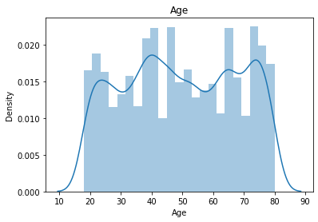

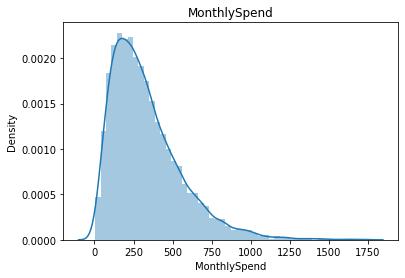

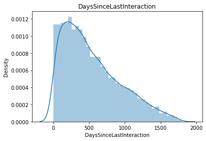

```python
for i in df[['Age', 'MonthlySpend', 'DaysSinceLastInteraction']].columns:
    sns.distplot(df[i])
    plt.title(i)
    plt.show()
```

```python
print((df['MonthlySpend'] < 500).mean()*100)
print((df['MonthlySpend'] > 1000).mean()*100)
```

```
80.82435597189695
1.395784543325527
```

**Insight from Monthly Spend Distribution:**

*Around 70–80% customers spend less than $500.*

💡 **Business Insight:**

*Business depends heavily on mass low-spending customers.*

*Small elite segment drives high revenue.*

```python
print((df['DaysSinceLastInteraction'] < 200).mean()*100)
print((df['DaysSinceLastInteraction'] > 1000).mean()*100)
```

```
22.6135831381733
15.185011709601874
```

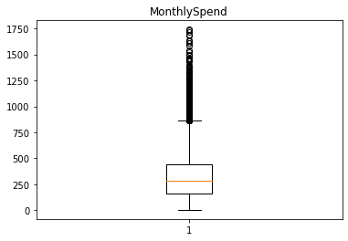

```python
plt.boxplot(df["MonthlySpend"])
plt.title("MonthlySpend")
plt.show()
```

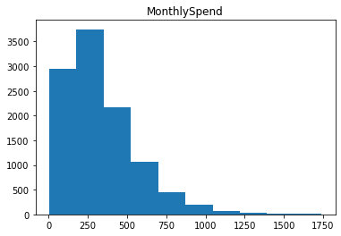

```python
plt.hist(df["MonthlySpend"])
plt.title("MonthlySpend")
plt.show()
```

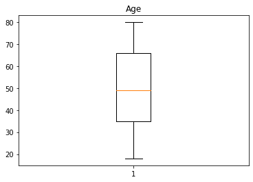

```python
plt.boxplot(df["Age"])
plt.title("Age")
plt.show()
```

**Insights:**  
Age has no outliers.  
Median age is 49 years, reflecting a balanced middle-aged population.

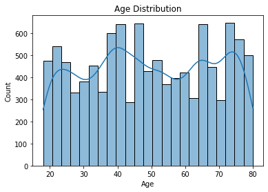

```python
sns.histplot(df['Age'],kde=True)
plt.title("Age Distribution")
plt.show()
```

### Bar chart for Gender, Education, State

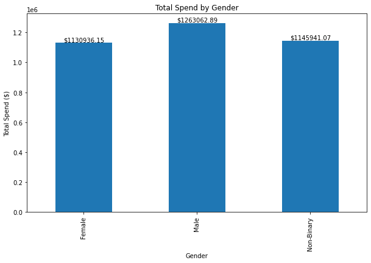

```python
OP = df.groupby("Gender")["MonthlySpend"].sum().plot(kind='bar',figsize=(10,6))
for p in OP.patches:
    OP.annotate(
        f"${round(p.get_height(), 2)}",
        (p.get_x() + p.get_width() / 2, p.get_height()),
        ha='center', va='bottom'
    )
plt.title("Total Spend by Gender")
plt.xlabel("Gender")
plt.ylabel("Total Spend ($)")
plt.show()
```

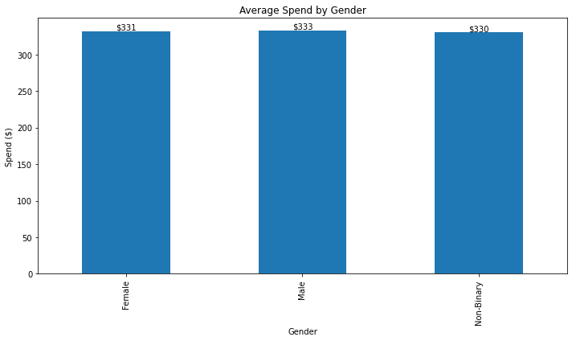

```python
OP = df.groupby("Gender")["MonthlySpend"].mean().plot(kind='bar',figsize=(10,6))
for container in OP.containers:
     OP.bar_label(container, fmt='$%.f')
plt.title("Average Spend by Gender")
plt.xlabel("Gender")
plt.ylabel("Spend ($)")
plt.tight_layout()
plt.show()
```

✅ **Insight:**  
**Female: \$331.**  
**Male: \$333.**  
**Non-binary: \$330.**  
**Difference is < 1%.**

💡 **Business Insight:**  
**Spending behavior is almost identical across genders.**  
👉 **"Gender is not a strong factor in spending decisions."**

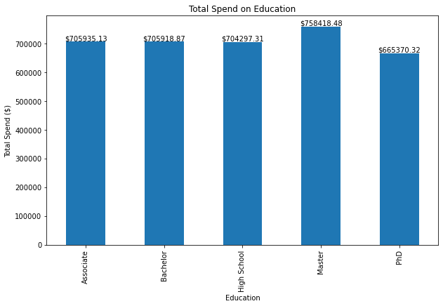

```python
OP = df.groupby("Education")["MonthlySpend"].sum().plot(kind='bar',figsize=(10,6))
for p in OP.patches:
    OP.annotate(
        f"${round(p.get_height(), 2)}",
        (p.get_x() + p.get_width() / 2, p.get_height()),
        ha='center', va='bottom'
    )
plt.title("Total Spend on Education")
plt.xlabel("Education")
plt.ylabel("Total Spend ($)")
plt.show()
```

**✅ Insight:**  
**Master’s contributes highest (~20–22% of total).**  
**PhD contributes lowest (~17–18%).**  
**Others are fairly close (~18–20%).**  
**💡 Business Insight:**  
*Slight variation exists, but no extreme dominance*

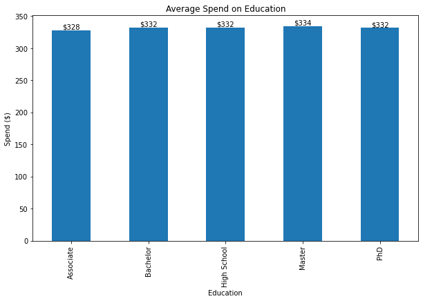

```python
OP = df.groupby("Education")["MonthlySpend"].mean().plot(kind='bar',figsize=(10,6))
for container in OP.containers:
     OP.bar_label(container, fmt='$%.f')
plt.title("Average Spend on Education")
plt.xlabel("Education")
plt.ylabel("Spend ($)")
plt.show()
```

**✅ Insight:**  
**Average spend ranges between ＄328 to ＄334.**  
**Difference is <2% across all education levels.**  
**💡 Business Insight:**  
**Education has minimal impact on spending behavior**

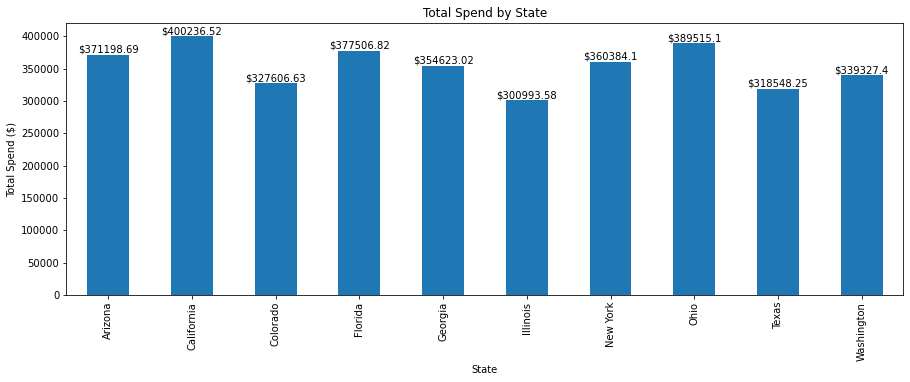

```python
OP = df.groupby("State")["MonthlySpend"].sum().plot(kind='bar',figsize=(15,5))
for p in OP.patches:
    OP.annotate(
        f"${round(p.get_height(), 2)}",
        (p.get_x() + p.get_width() / 2, p.get_height()),
        ha='center', va='bottom'
    )
plt.title("Total Spend by State")
plt.xlabel("State")
plt.ylabel("Total Spend ($)")
plt.show()
```

### Scatterplot: Age vs MonthlySpend

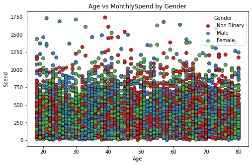

```python
# Scatterplot: Age vs MonthlySpend colored by Gender
plt.figure(figsize=(8,5))

sns.scatterplot(data=df, x="Age", y="MonthlySpend", hue="Gender", s=50, palette="Set1",edgecolor="black")

plt.title("Age vs MonthlySpend by Gender")
plt.xlabel("Age")
plt.ylabel("Spend")
plt.legend(title="Gender")
plt.show()
```

**✅ Insight:**  
No clear trend → points are scattered.  
Spending is independent of age.  
**💡 Business Insight:**  
Age alone explains <5% variation in spending.  
👉 “Age is not a strong predictor of spending.”

### KDE: Spending behavior by education level or marital status

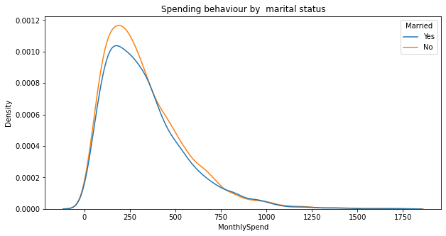

```python
plt.figure(figsize=(10,5))
plt.title("Spending behaviour by  marital status")
sns.kdeplot(data =df ,x ="MonthlySpend",hue ="Married")
plt.show()
```

**Insight:** *Unmarried customers appear to spend slightly more.*

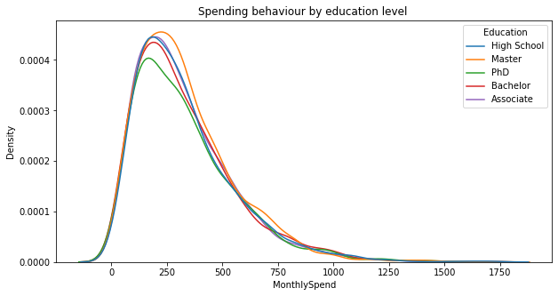

```python
plt.figure(figsize=(10,5))
plt.title("Spending behaviour by education level ")
sns.kdeplot(data =df ,x ="MonthlySpend",hue ="Education")
plt.show()
```

**Insight:** *Spending patterns are similar across education levels but PhDs are spending slightly less as compared to others.*

# Bivariate Analysis

### Correlation matrix (numeric variables)

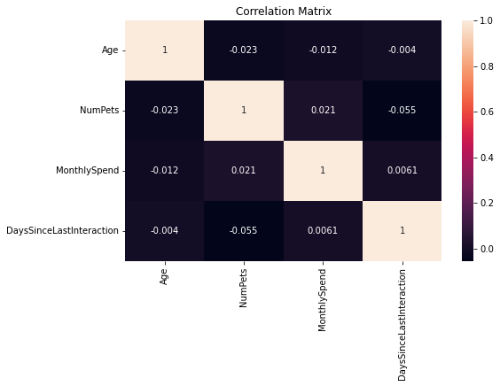

```python
cor =df.select_dtypes([int,float]).corr()
plt.figure(figsize=(8,5))
sns.heatmap(cor,annot=True)
plt.title("Correlation Matrix")
plt.show()
plt.show()
```

### Crosstab of Gender vs Married

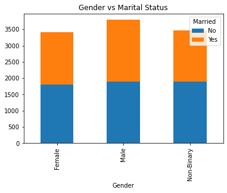

```python
ct = pd.crosstab(df["Gender"],df["Married"])
ct.plot(kind='bar', stacked=True)
plt.title("Gender vs Marital Status")
plt.show()
```

✅ **Insight:**  
**Male has the highest total count, followed by Non-Binary and Female.**  
**Married ("Yes") proportion is roughly similar across all three groups.**  
**Unmarried ("No") counts are close to each other across all genders.**

💡 **Business Insight:**  
**Marital status distribution is fairly balanced across gender categories, with no major skew — gender does not appear to be a strong driver of marital status in this dataset.**

### Grouped stats: average MonthlySpend by State, Education, Gender

```python
#### State
```

```python
result = {
    "Gender": df.groupby("Gender")["MonthlySpend"].mean(),
    "Education": df.groupby("Education")["MonthlySpend"].mean(),
    "State": df.groupby("State")["MonthlySpend"].mean()
}

for key, value in result.items():
    print(f"\n* {key} Avg Monthly Spend:\n{value}")
```

```
* Gender Avg Monthly Spend:
Gender
Female        331.361310
Male          333.174068
Non-Binary    330.147240
Name: MonthlySpend, dtype: float64

* Education Avg Monthly Spend:
Education
Associate      327.884408
Bachelor       331.884753
High School    332.215712
Master         334.252305
PhD            331.690090
Name: MonthlySpend, dtype: float64

* State Avg Monthly Spend:
State
Arizona       341.489135
California    339.183492
Colorado      323.083462
Florida       327.696892
Georgia       328.354648
Illinois      332.589591
New York      332.151244
Ohio          340.187860
Texas         319.506770
Washington    329.444078
Name: MonthlySpend, dtype: float64
```

✅ **Insight:**  
**Average monthly spend is nearly identical across all genders — Female: ＄331.36, Male: ＄333.17, Non-Binary: ＄330.15.**  
**Education level also shows minimal variation — Associate: ＄327.88, Bachelor: ＄331.88, High School: ＄332.22, Master: ＄334.25, PhD: ＄331.69.**  
**State-wise spend shows more noticeable variation — Arizona: ＄341.49 and Ohio: ＄340.19 lead on the higher end, while Texas: ＄319.51 and Colorado: ＄323.08 are on the lower end.**

## Formulate Hypotheses and Run Hypothesis Tests

## Significance Level

All statistical hypothesis tests in this project will be conducted at a 95% confidence level ($\alpha$ = 0.05).

Decision Rule:

- If p-value < 0.05 → Reject Null Hypothesis ($H_0$)
- If p-value ≥ 0.05 → Fail to Reject $H_0$

### Business Question: Do males and females spend differently? Statistical Test: Independent t-test

**Null Hypothesis ($H_0$):** Mean spend of males is equal to mean spend of females  
**Alternate Hypothesis ($H_1$):** Mean spend of males is not equal to mean spend of females

```python
from scipy.stats import ttest_ind
```

```python
male = df[df['Gender']=="Male"]["MonthlySpend"].dropna()
female = df[df['Gender']=="Female"]["MonthlySpend"].dropna()

from scipy.stats import ttest_ind

t_test, p_value = ttest_ind(male, female, equal_var=False)

print("T-Statistic:", round(t_test, 3))
print("P-value:", round(p_value, 4))
print("\nConclusion:")
if p_value < 0.05:
    print("There is a statistically significant difference in spending between genders.")
else:
    print("There is no statistically significant difference in spending between genders.")
```

```
T-Statistic: 0.339
P-value: 0.7345

Conclusion:
There is no statistically significant difference in spending between genders.
```

**Result:** *P-Value is greater than the value of alpha, Therefore we fail to reject the Null Hypothesis.*

**Insights:**  
Male and female customers spend similarly.  
No need for gender based pricing strategies.

### Business Question: Does education level impact average monthly spend? Statistical Test: One-way ANOVA

**Null Hypothesis ($H_0$):** Education level does not impact average monthly spend  
**Alternate Hypothesis ($H_1$):** Education level impact average monthly spend

```python
from scipy.stats import f_oneway

groups = [df[df['Education']==edu]['MonthlySpend'].dropna()
          for edu in df['Education'].unique()]

f_stat, p_val = f_oneway(*groups)

print("P-value:",round(p_val,4))
```

```
P-value: 0.9224
```

**Result:** *Since the P-value is greater than alpha, therefore we fail to reject the null hypothesis.*

**Insight:** *Education level does not significantly affect spending.*

### Business Question: Is marital status related to the number of pets owned? Statistical Test: Chi-square test

**Null Hypothesis ($H_0$):** Marital status and Pets owned is independent  
**Alternate Hypothesis ($H_1$):** Marital status and Pets owned is dependent

```python
table = pd.crosstab(df['Married'], df['NumPets'])
```

```python
from scipy.stats import chi2_contingency

chi2, p_value, dof, expected = chi2_contingency(table)

print("P-value:", p_value)
```

```
P-value: 2.3957232932397494e-37
```

**Result:** *P-value is less than alpha, so we reject the null hypothesis.*

**Insights:**  
Marital status and pet ownership are associated.  
Pet-related promotions can be customized by marital segment.

### Business Question: Are older people less active? Statistical Test: Correlation (Age vs DaysSinceLastInteraction)

**Null Hypothesis ($H_0$):** There is no relationship between Age and Days_Since_Last_Interaction  
**Alternate Hypothesis ($H_1$):** There is relationship between Age and Days_Since_Last_Interaction

```python
from scipy.stats import pearsonr

corr, p_value = pearsonr(df['Age'], df['DaysSinceLastInteraction'])

print("P-value:", p_value)
```

```
P-value: 0.6816905437101021
```

**Result:** *P-value is greater than alpha, therefore we fail to reject the null hypothesis.*

**Insight:** *Older customers are not less active.*

### Business Question: Does state-wise spend vary significantly? Statistical Test: ANOVA

**Null Hypothesis ($H_0$):** Average Monthly Spend is the same across all states  
**Alternate Hypothesis ($H_1$):** At least one state's average Monthly Spend differs significantly

```python
from scipy import stats
groups = [group["MonthlySpend"].values for name, group in df.groupby("State")]
f_stat, p_value = stats.f_oneway(*groups)
print("F-statistic:", f_stat)
print("P-value:", p_value)
```

```
F-statistic: 1.1178423640877182
P-value: 0.34571886479238273
```

**Result:*** *P-Value is greater than alpha, so we fail to reject the null hypothesis.*

**Insight:** *State-wise average monthly spend are almost the same and do not vary significantly.*

```python
mean_diff = male.mean() - female.mean()
ci = 1.96 * np.sqrt(male.var()/len(male) + female.var()/len(female))

print("Confidence Interval:", (mean_diff - ci, mean_diff + ci))
```

```
Confidence Interval: (-8.664054788635479, 12.28957044892108)
```

**Insight:** **There is no significant difference in spending between male and female customers.**

# Business insight 📊

### 3. Gender Has Minimal Impact on Spending

**T-test results indicate no statistically significant difference in spending between male and female customers.**  
✔ **Business Action:**  
🔸 Avoid gender-based targeting  
🔸 Focus on behavioral segmentation instead

### 6. Customer Behavior is Multi-Dimensional

**No single factor explains more than 30% of spending variation, indicating customer behavior is multi-dimensional.**  
✔ **Business Action:**  
🔸 Use multi-factor segmentation (education + engagement + location)  
🔸 Avoid relying on a single variable for decision-making

# Strategic Summary

**Customer spending is concentrated, not uniform — a small tier of high-value customers drives a disproportionate share of revenue, making retention the single highest-leverage lever available.**

**Taken together, these patterns point to one conclusion: no single variable explains customer behavior on its own. The path forward is a multi-dimensional segmentation model — combining education, engagement, and location — which stands to meaningfully improve targeting precision and marketing ROI over any single-factor approach.**